# Project3

Dylan Bauer, Prajwal Bhandari, Cameron Moore

April 28, 2025

## Front Matter

```r
library(tidyverse)
library(readxl)
library(glmnet)
library(rpart)
library(rattle)
cod <- read_excel('CODGames2_mp.xlsx', sheet = 1)
```

# data cleaning (same procedure as mp1 and mp2 )

```r
cod_working <- cod %>%
  rename(
    map1 = Map1,
    map2 = Map2,
    choice = Choice,
    map_vote = MapVote,
    date = Date,
    full_partial = FullPartial,
    result = Result,
    eliminations = Eliminations,
    deaths = Deaths,
    score = Score,
    damage = Damage,
    total_xp = TotalXP,
    primary_weapon = PrimaryWeapon,
    xp_multiplier = XPType, # call this multiplier, will convert in next command
    did_player_vote = DidPlayerVote,
    game_type = GameType,
    confirms = Confirms,
    denies = Denies,
    objectives = Objectives,
    objective_kills = ObjectiveKills,
    captures = Captures,
    diffuses = Diffuses,
    plants = Plants,
    detonates = Detonates,
    deposits = Deposits,
    time_sec = Time_Sec,
    time_min = Time_Min
  ) %>%
  mutate(  # for now, only mutating variables we think are important
    map1 = as.factor(map1),
    map2 = as.factor(map2),
    choice = as.factor(choice),
    full_partial = as.factor(full_partial),
    primary_weapon = as.factor(primary_weapon),
    xp_multiplier = if_else(xp_multiplier == '10% Boost', 1.10, 2.10),
    did_player_vote = as.logical(if_else(did_player_vote == 'Yes',1,0)),
  ) %>%
  separate(result, into = c('team_result', 'other_team_result'), sep = '-', extra = 'merge', convert = TRUE)

# drop columns with a lot of NA values, so count the values first
apply(cod_working, MARGIN = 2, FUN = function(x) sum(is.na(x))) # counts total NA in columns
```

```
##              map1              map2            choice          map_vote
##                43                43                 1                43
##              date      full_partial       team_result other_team_result
##                 0                 0                 0                 0
##      eliminations            deaths             score            damage
##                 0                 0                 0                 0
##          total_xp    primary_weapon     xp_multiplier   did_player_vote
##                 0                 0                 0                 0
##         game_type          confirms            denies        objectives
##                 0               208               208               205
##   objective_kills          captures          diffuses            plants
##               200               208               211               211
##         detonates          deposits          time_sec          time_min
##               211               211               203               203
```

```r
# since NA values are either < 50 or >200 drop all columns with more than 200 NA values
cod_working <- cod_working %>%
  select(where(~ sum(is.na(.)) < 200))
```

1. In order to help you to understand more of the variables in the dataset, this problem uses ‘TotalXP’, ‘XPType’ and ‘FullPartial’.

• The ‘FullPartial’ variable takes on two values: Full or Partial. These values are a reference as to whether the player participated in the full match or only a part of the match. (Sometimes when joining a new game, a player is added to a match that is already in progress. This is indicated by a value of Partial in the FullPartial variable.) Since it is not fair to compare the total experience points earned (TotalXP) for a match in which the player only participated in a fraction of the match to the TotalXP for a match in which the player participated in the entire match, we want to remove the cases in which the player only participated in a fraction of the match.

```r
cod_working <-
  cod_working %>%
  filter(full_partial == "Full")
```

• The type of experience points earned (‘XPType’) variable takes on one of two possible values: 10% Boost and Double XP + 10%. This variable is a reference to the way that the game calculates the number of experience points (XP) As an example, suppose that capturing an enemy location earns the player 50 experience point.s (XP). With the 10% Boost scoring, the player earns 55 experience points (50 + 50*0.1). Under the Double XP + 10%, the player would earn 105 experience points (50*2 + 50*0.1).

After removing the cases in which the player only participated in a fraction of the match, create side-by- side boxplots showing the relationship between TotalXP and XPType. (Be sure to use proper axis labels rather than the variable names.) Supplement the plots with summary statistics of TotalXP for each level of XPType. What have you learned about the relationship between XPType and TotalXP?

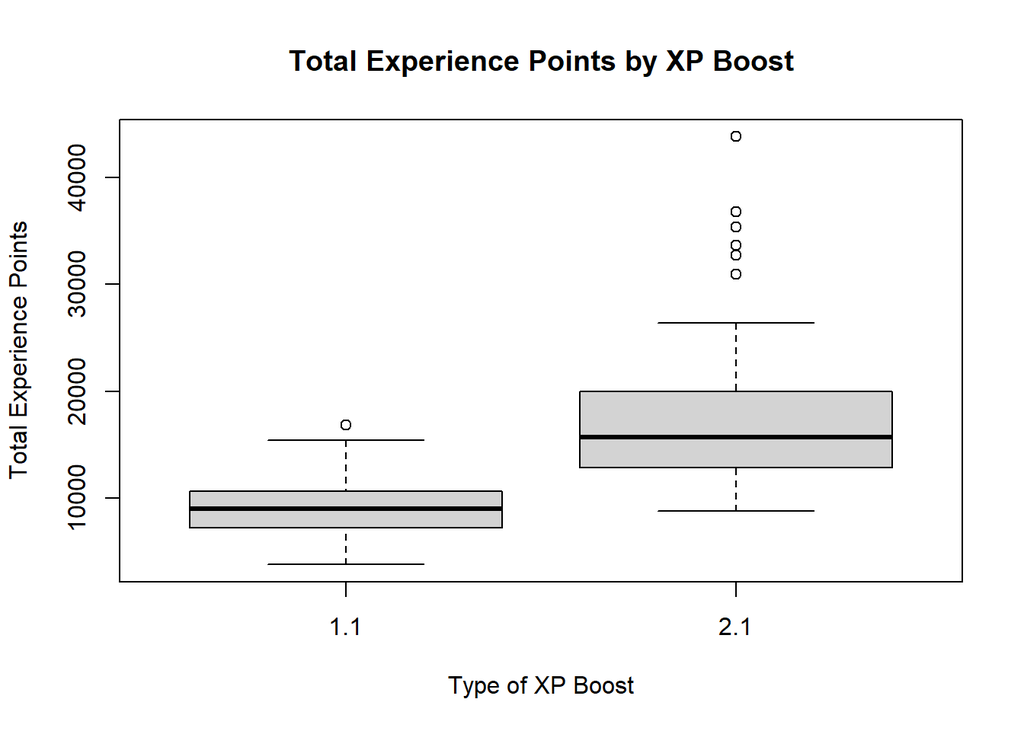

```r
boxplot(total_xp ~ xp_multiplier, data = cod_working,
        main = "Total Experience Points by XP Boost",
        xlab = "Type of XP Boost",
        ylab = "Total Experience Points")
```

```r
cod_working %>%
  group_by(xp_multiplier) %>%
  summarise(
    count = n(),
    min = min(total_xp),
    q1 = quantile(total_xp, 0.25),
    median = median(total_xp),
    mean = mean(total_xp),
    q3 = quantile(total_xp, 0.75),
    max = max(total_xp),
    sd = sd(total_xp)
  )
```

```
## # A tibble: 2 × 9
##   xp_multiplier count   min     q1 median   mean     q3   max    sd
##           <dbl> <int> <dbl>  <dbl>  <dbl>  <dbl>  <dbl> <dbl> <dbl>
## 1           1.1   111  3795  7216    9039  9094. 10650. 16831 2606.
## 2           2.1    80  8772 12909.  15738 17242. 19985. 43816 6649.
```

After filtering to full matches, we compared TotalXP between players with a 10% Boost and players with Double XP + 10%. The boxplots show that players with Double XP + 10% earned much higher TotalXP on average. Summary statistics support this: the mean TotalXP under Double XP + 10% was significantly higher, although with greater spread ($\sigma$ = 6649 vs $\sigma$ = 2606) compared to the 10% Boost group.

Thus, the type of XP boost clearly impacts the total experience points earned.

2. Suppose we wish to build an appropriate model for modeling the Score variable for games in which the player participated in the full match of a HC – TDM game type. We wish to answer the following research question: Of the predictors total XP, eliminations, deaths, damage, XPType, and whether the player’s team won, which should be included in a model for the Score? To answer this, you will have to create a new variable that indicates whether the player was on the winning team or not. NOTE: Since this is an inference question and we are not worried about how well the model will generalize to new data, there is no need to do a training/validation split in this problem.

```r
# add column to indicate if players team won (strictly larger)
cod_working$winning_team <- if_else(cod_working$team_result > cod_working$other_team_result, 1, 0)
# new df just for this question
cod_q2 <- cod_working %>% filter(game_type == 'HC - TDM')
```

1. Implement LASSO regression and one other feature selection procedure that we covered in Lecture
15. Include relevant plots, a discussion on which value of lambda you selected, the estimated equation from LASSO and the estimated equation from the second method. Discuss/compare the results of LASSO with those of the other method.

Since we want to implement a lasso model and also select a value of lambda, it makes sense to use a cross validation approach to get the best lasso model.

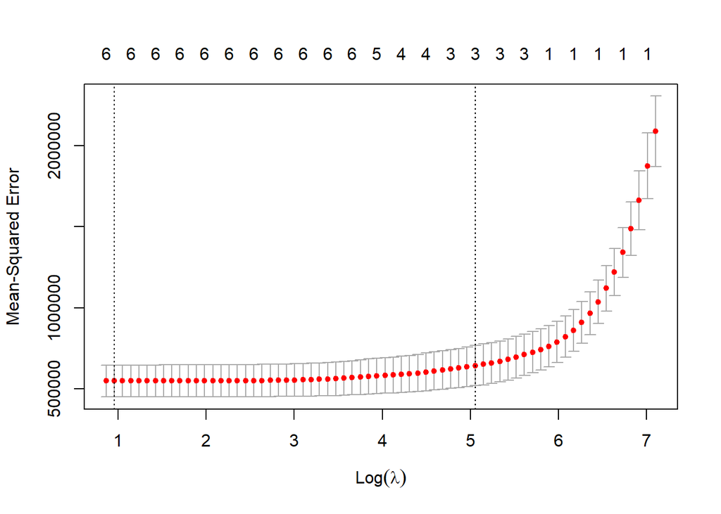

```r
# preparing data before modeling. (we will use xp_multiplier to stand as the xp_type variable since they are functionally the same thing)
xmat = model.matrix(score ~ total_xp + eliminations + deaths + damage + xp_multiplier + winning_team, data = cod_q2)[,-1]
ymat <- cod_q2$score
# implementing regression with CV LASSO selection
set.seed(123)
lasso_model <- cv.glmnet(x = xmat, y = ymat, lambda = NULL, standardize = T, nfolds = 10)
plot(lasso_model)
```

```r
# get coefficients from the lasso model with the minimum square error
lasso_coeff <- predict(lasso_model, s = lasso_model$lambda.min, type = 'coefficients')
lasso_coeff
```

```
## 7 x 1 sparse Matrix of class "dgCMatrix"
##                          s1
## (Intercept)   1334.88999023
## total_xp         0.05984054
## eliminations   159.12937918
## deaths         -72.77820466
## damage           0.94772672
## xp_multiplier -361.57550500
## winning_team  -447.19199686
```

```r
# implementing lm with backwards best subset selection with AIC scoring
null_model = lm(score ~ 1, data = cod_q2)
full_model = lm(score ~ total_xp + eliminations + deaths + damage + xp_multiplier + winning_team, data = cod_q2)

step(object = full_model, scope = list(lower = null_model, upper = full_model), method = 'backwards')
```

```
## Start:  AIC=2342.53
## score ~ total_xp + eliminations + deaths + damage + xp_multiplier +
##     winning_team
##
##                 Df Sum of Sq      RSS    AIC
## - damage         1    119968 85565679 2340.8
## <none>                       85445711 2342.5
## - eliminations   1   2766940 88212652 2346.2
## - xp_multiplier  1   3222207 88667919 2347.1
## - winning_team   1   7727591 93173302 2355.9
## - total_xp       1  10431500 95877211 2361.0
## - deaths         1  11752728 97198439 2363.5
##
## Step:  AIC=2340.78
## score ~ total_xp + eliminations + deaths + xp_multiplier + winning_team
##
##                 Df Sum of Sq       RSS    AIC
## <none>                        85565679 2340.8
## + damage         1    119968  85445711 2342.5
## - xp_multiplier  1   3103670  88669349 2345.1
## - winning_team   1   7627935  93193614 2354.0
## - total_xp       1  10318883  95884562 2359.0
## - deaths         1  11660493  97226172 2361.5
## - eliminations   1 118217717 203783396 2493.2
```

```
##
## Call:
## lm(formula = score ~ total_xp + eliminations + deaths + xp_multiplier +
##     winning_team, data = cod_q2)
##
## Coefficients:
##   (Intercept)       total_xp   eliminations         deaths  xp_multiplier
##    1348.78702        0.06054      185.24081      -73.25104     -367.94000
##  winning_team
##    -454.44701
```

2. (This material will be finished in lecture by Wednesday, April 23.) Build a regression tree for predicting Score using total XP, eliminations, deaths, damage, XPType, and whether the player’s team won. Specify that each node must contain at least 15 observations. Display the tree and report the variables associated with the 3 highest variable importance values. (Include the variable importance values when mentioning the variables.)

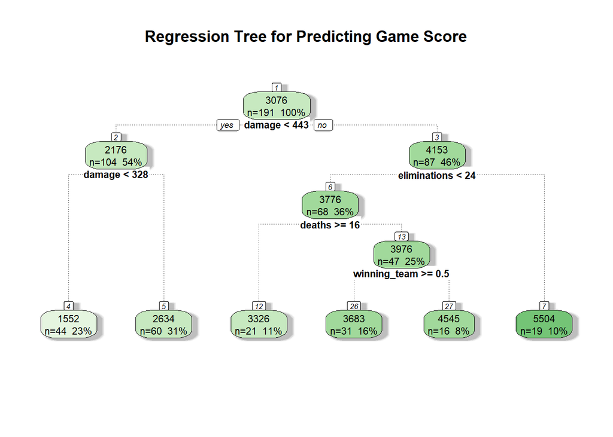

```r
RegTree <- rpart(score ~ total_xp + eliminations + deaths + damage + xp_multiplier + winning_team,
                 method = "anova",
                 data = cod_working,
                 minbucket = 15)

fancyRpartPlot(RegTree,
               cex = .7,
               main = 'Regression Tree for Predicting Game Score',
               sub = "")
```

```r
print(100*RegTree$variable.importance/sum(RegTree$variable.importance))
```

```
##        damage  eliminations      total_xp        deaths  winning_team
##     39.631927     37.356332     10.962502      6.545239      3.524273
## xp_multiplier
##      1.979727
```

3. When building linear regression models, we often wish to determine which variables are the most important. One way of doing this is to look at the magnitude (absolute value) of the estimated coefficients for the regression model built using standardized inputs (centered to have a mean of 0 and a standard deviation of 1). Based on the variables selected by the other feature selection procedure from part a. (in other words, not the LASSO model), standardize the inputs, build the regression model, report the estimated equation, and report the 3 most important variables based on the magnitude (absolute value) of the estimated coefficients. How does this compare to the most important variables based on the regression tree?

```r
xvars = c('total_xp', 'eliminations', 'deaths', 'xp_multiplier', 'winning_team')

cod_q2_standardized <- cod_q2

cod_q2_standardized[, xvars] <- scale(cod_q2[, xvars], center = T, scale = T)

standard_model <- lm(score ~ total_xp + eliminations + deaths + xp_multiplier + winning_team, data = cod_q2_standardized)

summary(standard_model)
```

```
##
## Call:
## lm(formula = score ~ total_xp + eliminations + deaths + xp_multiplier +
##     winning_team, data = cod_q2_standardized)
##
## Residuals:
##      Min       1Q   Median       3Q      Max
## -2000.77  -444.28   -35.43   327.75  2912.93
##
## Coefficients:
##               Estimate Std. Error t value Pr(>|t|)
## (Intercept)    3104.95      52.87  58.733  < 2e-16 ***
## total_xp        382.88      84.07   4.554 9.91e-06 ***
## eliminations   1030.92      66.88  15.415  < 2e-16 ***
## deaths         -276.49      57.11  -4.841 2.86e-06 ***
## xp_multiplier  -182.80      73.19  -2.498  0.01344 *
## winning_team   -226.12      57.75  -3.916  0.00013 ***
## ---
## Signif. codes:  0 '***' 0.001 '**' 0.01 '*' 0.05 '.' 0.1 ' ' 1
##
## Residual standard error: 705.3 on 172 degrees of freedom
## Multiple R-squared:  0.7697, Adjusted R-squared:  0.763
## F-statistic:   115 on 5 and 172 DF,  p-value: < 2.2e-16
```

Using the predictors selected by backward stepwise selection, we standardized total_xp, eliminations, deaths, xp_multiplier, and winning_team before fitting a linear regression model. Based on the magnitude of the standardized coefficients, the three most important variables were eliminations (coefficient = 1030.92), total_xp (coefficient = 382.88), and deaths (coefficient = -276.49). Eliminations had by far the largest impact on the player’s score among the predictors. Compared to the regression tree, which also highlighted eliminations and damage as important variables, the standardized regression model confirmed that eliminations is the strongest predictor, while total_xp and deaths also had substantial effects.

## Discussion of group contributions

Dylan and Prajwal worked on the code while Cameron did the write up. We found that doing all the code first and then write up second allowed for a more consistent code and writing style throughout the project.